# Proportion of Brazil as the affiliation of documents in SciELO Brazil

Our goal is to find the proportion of Brazil in the affiliations of documents belonging to the SciELO Brazil collection. Let $d$ be a document, then the proportion we’re looking for is:

$$p(d) = \frac{\text{number of affiliations of} \; d \; \text{in Brazil}}
{\text{total number of affiliations of} \; d}$$

We’re going to study the $p(d)$ on an yearly basis, counting only the affiliations whose country we know.

Let’s load from SciELO Analytics the CSV of documents affiliations in SciELO Brazil:

```r
# We shouldn't interpret Namibia (NA) as "not available"
doc_aff <- read.csv("tabs_bra/documents_affiliations.csv", na.strings = c())
dim(doc_aff) # Number of rows and columns
```

```
## [1] 804928     26
```

```r
as.data.frame(t(head(doc_aff, 1))) # First entry
```

|  | 1 |
| --- | --- |
| extraction.date | 2018-09-13 |
| study.unit | document |
| collection | scl |
| ISSN.SciELO | 0100-879X |
| ISSN.s | 0100-879X;1414-431X |
| title.at.SciELO | Brazilian Journal of Medical and Biological Research |
| title.thematic.areas | Biological Sciences;Health Sciences |
| title.is.agricultural.sciences | 0 |
| title.is.applied.social.sciences | 0 |
| title.is.biological.sciences | 1 |

[output cut: 16 more lines]

R already simplifies the column names in some sense, replacing the whitespaces and special characters by a dot. We can see the names with `names(doc_aff)`.

Categorical fields are known as *factors*.

```r
class(doc_aff$document.type)
```

```
## [1] "factor"
```

```r
class(doc_aff$document.affiliation.country.ISO.3166)
```

```
## [1] "factor"
```

The *levels* of a factor are the values one *factor* vector can have.

```r
levels(doc_aff$document.type)
```

```
##  [1] "abstract"            "addendum"            "article-commentary"
##  [4] "book-review"         "brief-report"        "case-report"
##  [7] "correction"          "editorial"           "letter"
## [10] "news"                "press-release"       "rapid-communication"
## [13] "research-article"    "review-article"      "undefined"
```

```r
levels(doc_aff$document.affiliation.country.ISO.3166)
```

```
##   [1] ""   "AE" "AG" "AL" "AM" "AN" "AO" "AR" "AS" "AT" "AU" "AZ" "BA" "BB"
##  [15] "BD" "BE" "BF" "BG" "BH" "BI" "BJ" "BO" "BR" "BS" "BT" "BW" "BY" "CA"
##  [29] "CD" "CF" "CH" "CI" "CL" "CM" "CN" "CO" "CR" "CS" "CU" "CV" "CY" "CZ"
##  [43] "DE" "DK" "DO" "DZ" "EC" "EE" "EG" "ES" "ET" "FI" "FJ" "FR" "GA" "GB"
##  [57] "GD" "GE" "GF" "GH" "GN" "GP" "GR" "GT" "GW" "GY" "HK" "HN" "HR" "HT"
##  [71] "HU" "ID" "IE" "IL" "IN" "IQ" "IR" "IS" "IT" "JM" "JO" "JP" "KE" "KG"
##  [85] "KN" "KR" "KW" "KY" "KZ" "LA" "LB" "LK" "LR" "LT" "LU" "LV" "LY" "MA"
##  [99] "ME" "MG" "MI" "MK" "ML" "MM" "MN" "MT" "MU" "MW" "MX" "MY" "MZ" "NA"
## [113] "NE" "NG" "NI" "NL" "NO" "NP" "NZ" "OM" "PA" "PE" "PG" "PH" "PK" "PL"
## [127] "PR" "PS" "PT" "PY" "QA" "RO" "RS" "RU" "RW" "SA" "SC" "SD" "SE" "SG"
## [141] "SI" "SK" "SL" "SN" "SR" "SS" "SU" "SV" "SY" "TG" "TH" "TL" "TN" "TR"
## [155] "TT" "TW" "TZ" "UA" "UG" "US" "UY" "VE" "VN" "YE" "YU" "ZA" "ZM" "ZW"
```

Most entries are research articles, we’ll work only with this document type:

```r
options(scipen = 6) # Avoid scientific notation in plots
```

```r
as.data.frame(summary(doc_aff$document.type))
```

|  | summary(doc_aff$document.type) |
| --- | --- |
| abstract | 3215 |
| addendum | 192 |
| article-commentary | 3396 |
| book-review | 7948 |
| brief-report | 7732 |
| case-report | 17602 |
| correction | 875 |
| editorial | 17827 |
| letter | 6122 |
| news | 111 |

[output cut: 5 more lines]

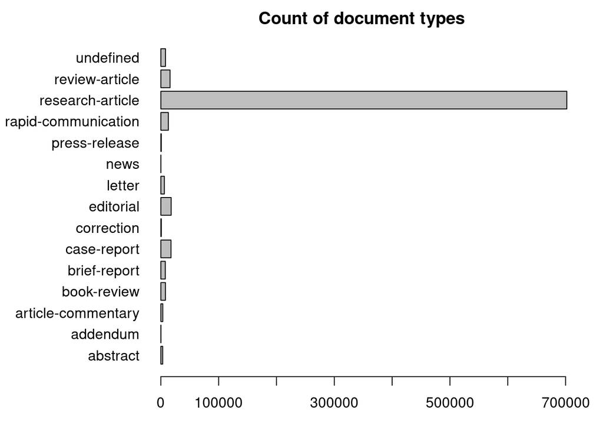

```r
par(mar = c(3, 9, 2, 2) + .1)
barplot(summary(doc_aff$document.type),
        horiz = TRUE,
        las = 1, # Horizontal labels
        main = "Count of document types")
```

```r
articles <- doc_aff[doc_aff$document.type == "research-article",]
nrow(articles)
```

```
## [1] 702149
```

Most affiliation entries are from Brazil (that’s somewhat expected for a Brazilian collection).

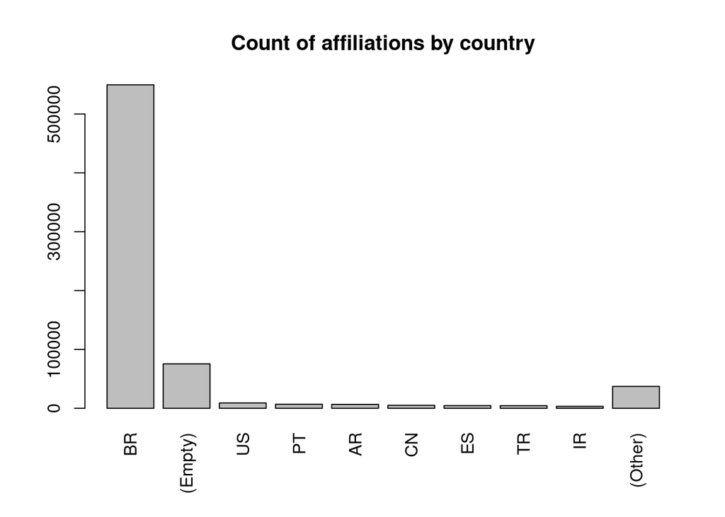

```r
aff_country_summary <- summary(articles$document.affiliation.country.ISO.3166,
                               maxsum = 10)
aff_country_summary_names <- replace(names(aff_country_summary),
                                     names(aff_country_summary) == "",
                                     "(Empty)")
acs_xmidpoints <- barplot(aff_country_summary,
                          axisnames = FALSE,
                          main = "Count of affiliations by country")
axis(1, at = acs_xmidpoints, las = 2,
        labels = aff_country_summary_names, xpd = TRUE,
        tick = FALSE)
```

Let’s build a dataset with just four columns:

- One regarding the document publication year;
- One regarding to the PID, a way to identify an article;
- One logical, `TRUE` if an article have a Brazilian affiliation;
- One logical, `TRUE` if an article have a non-Brazilian affiliation.

We should remove the empty country entries, since they might belong to any country (Brazil or other). Using two columns should be cleaner to understand than merging the Brazilian/non-Brazilian affiliation as a single column.

```r
dataset <- data.frame(
  articles$document.publishing.year,
  articles$document.publishing.ID..PID.SciELO.,
  articles$document.affiliation.country.ISO.3166 == "BR",
  grepl("[^B].|.[^R]", articles$document.affiliation.country.ISO.3166)
)
names(dataset) <- c("year", "pid", "br", "not_br")
dataset <- dataset[dataset$br | dataset$not_br,]
head(dataset)
```

|  | year | pid | br | not_br |
| --- | --- | --- | --- | --- |
| 624 | 1998 | S0074-02761998000300014 | TRUE | FALSE |
| 2319 | 1998 | S0102-76381998000400005 | TRUE | FALSE |
| 2321 | 1998 | S0102-76381998000400003 | TRUE | FALSE |
| 2323 | 1998 | S0102-76381998000400009 | TRUE | FALSE |
| 2333 | 1998 | S0102-76381998000400004 | TRUE | FALSE |
| 2334 | 1998 | S0102-76381998000400010 | TRUE | FALSE |

```r
nrow(dataset)
```

```
## [1] 626660
```

As all entries are either `br` or `not_br`, we just need to calculate the mean of `br` for each PID. We’ll use `dplyr` to group that result by the PID.

```r
library(dplyr) # Masks intersect, setdiff, setequal, union, filter, lag
```

```r
proportions <- dataset %>% group_by(pid) %>% summarize(mean(br), max(year))
proportions <- proportions[c(2, 3)]
names(proportions) <- c("prop", "year")
nrow(proportions)
```

```
## [1] 284274
```

```r
head(proportions)
```

| prop | year |
| --- | --- |
| 1 | 1998 |
| 1 | 1998 |
| 0 | 1998 |
| 1 | 1998 |
| 1 | 1998 |
| 1 | 1998 |

Let’s see the evolution of the mean of these proportions:

```r
mprops <- proportions %>% group_by(year) %>% summarize(mean(prop))
min(mprops$year, na.rm = TRUE) # Oldest document publication year
```

```
## [1] 1909
```

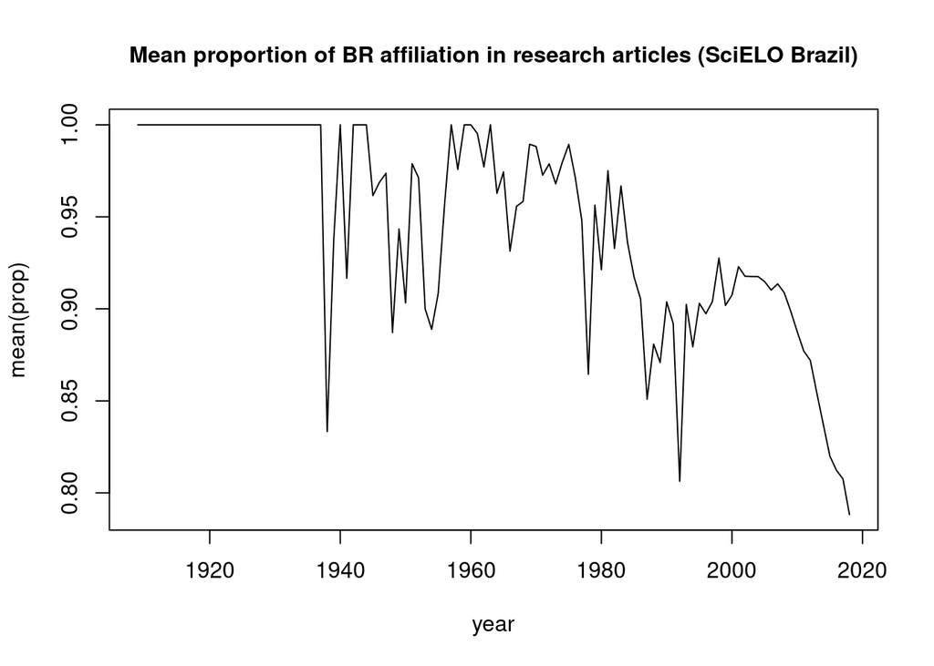

```r
plot(
  mprops,
  type = "l",
  cex.main = 1,
  main = paste("Mean proportion of BR affiliation",
               "in research articles (SciELO Brazil)",
               sep = " ")
)
```

The raw data:

```r
library(kableExtra)
mprops_all_years <- merge(data.frame(year = 1909:2018), mprops, all.x = TRUE)
mprops_all_years$year = as.character(mprops_all_years$year)
kable(
  cbind(mprops_all_years[seq(from = 1, length = 22),],
        mprops_all_years[seq(from = 23, length = 22),],
        mprops_all_years[seq(from = 45, length = 22),],
        mprops_all_years[seq(from = 67, length = 22),],
        mprops_all_years[seq(from = 89, length = 22),]),
  digits = 5, format.args = list(nsmall = 5),
) %>%
  kable_styling(latex_options = "striped") %>%
  add_header_above(c("1909-1930" = 2, "1931-1952" = 2, "1953-1974" = 2,
                     "1975-1996" = 2, "1997-2018" = 2))
```

| 1909-1930 year | 1909-1930 mean(prop) | 1931-1952 year | 1931-1952 mean(prop) | 1953-1974 year | 1953-1974 mean(prop) | 1975-1996 year | 1975-1996 mean(prop) | 1997-2018 year | 1997-2018 mean(prop) |
| --- | --- | --- | --- | --- | --- | --- | --- | --- | --- |
| 1909 | 1.00000 | 1931 | 1.00000 | 1953 | 0.90000 | 1975 | 0.98935 | 1997 | 0.90395 |
| 1910 | NA | 1932 | 1.00000 | 1954 | 0.88889 | 1976 | 0.97136 | 1998 | 0.92757 |
| 1911 | NA | 1933 | 1.00000 | 1955 | 0.90833 | 1977 | 0.94796 | 1999 | 0.90184 |
| 1912 | NA | 1934 | 1.00000 | 1956 | 0.95775 | 1978 | 0.86443 | 2000 | 0.90748 |
| 1913 | NA | 1935 | NA | 1957 | 1.00000 | 1979 | 0.95635 | 2001 | 0.92294 |
| 1914 | NA | 1936 | 1.00000 | 1958 | 0.97581 | 1980 | 0.92127 | 2002 | 0.91769 |
| 1915 | NA | 1937 | 1.00000 | 1959 | 1.00000 | 1981 | 0.97504 | 2003 | 0.91756 |
| 1916 | NA | 1938 | 0.83333 | 1960 | 1.00000 | 1982 | 0.93280 | 2004 | 0.91753 |
| 1917 | 1.00000 | 1939 | 0.93750 | 1961 | 0.99528 | 1983 | 0.96676 | 2005 | 0.91481 |
| 1918 | 1.00000 | 1940 | 1.00000 | 1962 | 0.97710 | 1984 | 0.93607 | 2006 | 0.91021 |
| 1919 | NA | 1941 | 0.91667 | 1963 | 1.00000 | 1985 | 0.91731 | 2007 | 0.91356 |
| 1920 | NA | 1942 | 1.00000 | 1964 | 0.96277 | 1986 | 0.90533 | 2008 | 0.90882 |
| 1921 | NA | 1943 | 1.00000 | 1965 | 0.97436 | 1987 | 0.85090 | 2009 | 0.89872 |
| 1922 | 1.00000 | 1944 | 1.00000 | 1966 | 0.93137 | 1988 | 0.88082 | 2010 | 0.88754 |
| 1923 | 1.00000 | 1945 | 0.96154 | 1967 | 0.95570 | 1989 | 0.87085 | 2011 | 0.87702 |
| 1924 | 1.00000 | 1946 | 0.96875 | 1968 | 0.95833 | 1990 | 0.90380 | 2012 | 0.87200 |
| 1925 | 1.00000 | 1947 | 0.97368 | 1969 | 0.98944 | 1991 | 0.89194 | 2013 | 0.85422 |
| 1926 | 1.00000 | 1948 | 0.88710 | 1970 | 0.98824 | 1992 | 0.80630 | 2014 | 0.83702 |
| 1927 | 1.00000 | 1949 | 0.94340 | 1971 | 0.97264 | 1993 | 0.90240 | 2015 | 0.81992 |
| 1928 | 1.00000 | 1950 | 0.90323 | 1972 | 0.97877 | 1994 | 0.87933 | 2016 | 0.81231 |
| 1929 | 1.00000 | 1951 | 0.97887 | 1973 | 0.96792 | 1995 | 0.90300 | 2017 | 0.80760 |
| 1930 | NA | 1952 | 0.97115 | 1974 | 0.97958 | 1996 | 0.89737 | 2018 | 0.78823 |

Is that significantly decreasing? To answer that, let’s consider the linear regression slope, which should be negative, that is, the mean proportion should get lower when the year gets higher.

```r
regr <- lm(mean.prop. ~ year, data.frame(mprops))
summary(regr)
```

```
##
## Call:
## lm(formula = mean.prop. ~ year, data = data.frame(mprops))
##
## Residuals:
##       Min        1Q    Median        3Q       Max
## -0.149550 -0.011874  0.005626  0.025461  0.058664
##
## Coefficients:
##               Estimate Std. Error t value Pr(>|t|)
## (Intercept)  3.7169339  0.2630088   14.13   <2e-16 ***
## year        -0.0014108  0.0001336  -10.56   <2e-16 ***
## ---
## Signif. codes:  0 '***' 0.001 '**' 0.01 '*' 0.05 '.' 0.1 ' ' 1
##
## Residual standard error: 0.03833 on 96 degrees of freedom
## Multiple R-squared:  0.5375, Adjusted R-squared:  0.5327
## F-statistic: 111.6 on 1 and 96 DF,  p-value: < 2.2e-16
```

The slope (the `year` estimate) is negative.

But is that negative for the $95\% \text{CI}$ range?

```r
confint(regr, level = .95)
```

```
##                    2.5 %       97.5 %
## (Intercept)  3.194865642  4.239002162
## year        -0.001675865 -0.001145654
```

Yes, it’s decreasing! The slope (`year`, last row of `confint` result) is negative for the entire $95\%$ confidence interval.